# Assignment 2

Group One

Once the required libraries are loaded, the first step is to extract the data using read_csv. This is saved as ‘Survey’ and remains unchanged. A copy is then created (Survey_tidy), that can be altered as data is tidied. This copy does not include the 64th row of data, as this is simply a row of NA values.

```r
library(readxl)
library(tidyverse)
library(stringr)
Survey <-read_csv("survey.csv")
Survey_tidy <- Survey[-c(64),]
```

Q1 - What year of uni are you in?

Firstly, the multi-choice options must be converted to their numeric equivalent, with E simply listed as other. This is done through the mutate and sub functions. Sub replaces the first argument (eg “A”), with the second (eg 1) when found in column Q1. Mutate is changing the old Q1 value to this new value from sub. This method is repeated throughout the data tidying process for every multichoice question, replacing the A-E values with their corresponding values from the survey.

```r
#Q1
Survey_tidy <- Survey_tidy %>%
  mutate(Q1 = sub("A", 1, Q1)) %>%
  mutate(Q1 = sub("B", 2, Q1)) %>%
  mutate(Q1 = sub("C", 3, Q1)) %>%
  mutate(Q1 = sub("D", 4, Q1)) %>%
  mutate(Q1 = sub("E", "other", Q1))
```

Q2 - How much time do you spend commuting to university each week?

In a perfect world, all respondents would input a single numeric value, however this is not the case. Some people have written fractions (1/2 instead of 0.5), while others have included the units (hours or similar variant after the value). To account for this, the same mutate and sub combination is used as in Q1, replacing the unwanted letters with nothing (represented by empty quotation marks). This method is particularly usefull if multiple people have added the same letters afterwards, as one line of code can change all common cases. In some cases the input is so different to the format required, it is easier to simply change the value manually. This was completed for respondent 27 who wrote ‘2 hours ( to uni)’ In this case, we have simply reassigned the 27th value a number of 2. Another respondent also answered three times, which does not answer the question. As such this asnwer is removed from the data, set to NA. The final step is to convert these values to numeric. Through these manipulations, some values have been stored as strings. This problem is easily solved in the last line for this chunk, where all values are converted.

```r
# Q2
Survey_tidy <- Survey_tidy %>%
   mutate(Q2 = sub("1/2", "0.5", Q2)) %>%
   mutate(Q2 = sub(" hours", "", Q2)) %>%
   mutate(Q2 = sub("\n", "", Q2)) %>%
   mutate(Q2 = sub("hrs", "", Q2)) %>%
   mutate(Q2 = sub("HOUR", "", Q2)) %>%
   mutate(Q2 = sub("4/7", "0.57", Q2)) %>%
   mutate(Q2 = sub("three times", NA, Q2))
Survey_tidy$Q2[27] <- "2.0"
Survey_tidy <- Survey_tidy %>% mutate(Q2 = as.numeric(Q2))
```

Q3- True/False: I attended Ed Sheeran’s concert in 2018?

No tidying is required for Q3, as the data is already in True/False form which is very easy to work with.

Q4 - What is your favourite/most listened to genre of music?

This is the first question with an input that should be a string, meaning there will be a high variation in responses. This first step is to make the entire data for this question lower case. This ensures answers such as pop and Pop are seen as the same thing. This is achieved through the use of the tolower function.

Similar answers must then be stored under the same answer. For example pop, pop music and popular music are all stored under pop. This process is ahcieved through the same use of mutate and sub. One example of note is removing the word music, for example classical music becoming just classical. Any cases of music are set to “”. Respondant 22 however simply stated music as their favourite, so this value was changed to ‘anything’ manually (it was assumed by answering music that they liked all music). Without this extra line, their answer would have been removed entirely. Respondant 46 did not answer, so their answer was set to NA.

Once sorted, the data is still varied due to the great number of genres available. As such a summary was created which states the counts of the genres, but only including genres with at least 4 responses. This data can then be more easily used to gain an insight into the most popular genres.

```r
#Q4
Survey_tidy <- Survey_tidy %>%
  mutate(Q4 = sapply(Survey_tidy[5], tolower)) %>%
  mutate(Q4 = sub("rnb", "r&b", Q4)) %>%
  mutate(Q4 = sub("alt rock", "alternative rock", Q4)) %>%
  mutate(Q4 = sub("music", "", Q4)) %>%
  mutate(Q4 = sub("-", " ", Q4)) %>%
  mutate(Q4 = sub("popular", "pop", Q4)) %>%
  mutate(Q4 = sub("rock and/or roll", "rock", Q4)) %>%
  mutate(Q4 = sub("hiphop", "hip hop", Q4)) %>%
  mutate(Q4 = sub("indie rock", "alternative rock", Q4))
Survey_tidy$Q4[22] <- "anything"
Survey_tidy$Q4[46] <- NA

music_summary <-  group_by(Survey_tidy, Q4) %>%
  summarise(count = n()) %>%
  filter(count >= 4)
```

Q5 - How much time do you spend on the internet each week?

Another case where a single numeric entry is expected, but did not always occur. As with question 2, the word hours and variants are removed, then the entire data is set to numeric values. Respondants 40 and 46 did not answer so their values are set to NA.

```r
#Q5
Survey_tidy <- Survey_tidy %>%
  mutate(Q5 = sub("hrs", "", Q5)) %>%
  mutate(Q5 = sub("hours", "", Q5)) %>%
  mutate(Q5 = sub("Hours", "", Q5)) %>%
  mutate(Q5 = sub("HOUR", "", Q5))
Survey_tidy$Q5[40] <- NA
Survey_tidy$Q5[46] <- NA
Survey_tidy <- Survey_tidy %>% mutate(Q5 = as.numeric(Q5))
```

Q6 - If you could have a super power what would it be?

Another open ended question, with great variation in responses. The exact same process as Q4 is followed, first converting to lower cases then replacing common variants under the one variant (eg flying and fly became flight). Due to the nature of the question, there are a large number of responses for the same superpower, but worded differently. In this case it is less efficient to mutate and sub for each variant. Instead the index number for the responses that can all be grouped as one, are all changed at the same time. For example respondants 57, 55 and 12 all responded with variations of time travel. The existing values are all completely replaced with the common ‘time travel’ tag.

As with music, due to the large variation even in the tidied data, a summary is created with superpowers that have at least 4 respondants.

```r
#Q6
Survey_tidy <- Survey_tidy %>%
  mutate(Q6 = sapply(Survey_tidy[7], tolower)) %>%
  mutate(Q6 = sub("flying", "flight", Q6)) %>%
  mutate(Q6 = sub("fly", "flight", Q6)) %>%
  mutate(Q6 = sub("teleporting", "teleportation", Q6)) %>%
  mutate(Q6 = sub("invisible", "invisibility", Q6))
Survey_tidy$Q6[c(57,55,12)] <- "time travel"
Survey_tidy$Q6[c(44,42,37)] <- "time control"
Survey_tidy$Q6[60] <- "immortality"
Survey_tidy$Q6[c(34,14)] <- "forecasting"
Survey_tidy$Q6[23] <- "nothing"
Survey_tidy$Q6[1] <- "speed"
Survey_tidy$Q6[30] <- "not needing sleep"
Survey_tidy$Q6[35] <- "never forget"

powers_summary <- group_by(Survey_tidy, Q6) %>%
  summarise(count = n()) %>%
  filter(count >= 4)
```

Q7 - Would you rather your shirts be always two sizes too big or one size too small?

For questions 7 and 8, the letter value is converted to the corresponding survey answer as with Q1.

```r
#Q7
Survey_tidy <- Survey_tidy %>%
  mutate(Q7 = sub("A", "too big", Q7)) %>%
  mutate(Q7 = sub("B", "too small", Q7)) %>%
  mutate(Q7 = sub("C", "neither", Q7))
```

Q8 - How many hours do you spend on study a week?

```r
#Q8
Survey_tidy <- Survey_tidy %>%
  mutate(Q8 = sub("A", "0-3", Q8)) %>%
  mutate(Q8 = sub("B", "3-6", Q8)) %>%
  mutate(Q8 = sub("C", "6-9", Q8)) %>%
  mutate(Q8 = sub("D", "9-12", Q8)) %>%
  mutate(Q8 = sub("E", "more than 12", Q8))
```

Q9 - Which streaming service do you use to watch television?

```r
#Q9
Survey_tidy <- Survey_tidy %>%
  mutate(Q9 = sapply(Survey_tidy[10], tolower))
Survey_tidy$Q9[c(33,41,62,21,40,55,23,57,3, 7, 19, 59, 32, 38)] <- "none"
Survey_tidy$Q9[12] <- NA
Survey_tidy$Q9[54] <- "foxtel"
Survey_tidy$Q9[39] <- "netflix"
Survey_tidy$Q9[11] <- "youtube"
```

Q10 - How many litres of water do you drink a day?

Answers for this question were typically a single number, as expected. One response was given simply as a question mark however, so this was replaced with “”. This value converts to NA when the values are all converted to numeric.

```r
#Q10
Survey_tidy<-Survey_tidy%>%
  mutate(Q10 = sub("?", "", Q10))
Survey_tidy <- Survey_tidy %>% mutate(Q10 = as.numeric(Q10))
```

Q11 - Are you taking this subject as an elective or core unit?

Q11 and 12 is simply converting from letter to answer as in Q1

```r
#Q11
Survey_tidy <- Survey_tidy %>%
  mutate(Q11 = sub("A", "elective", Q11)) %>%
  mutate(Q11 = sub("B", "core", Q11))
```

Q12 - Do you study a single or double degree?

```r
#Q12
Survey_tidy <- Survey_tidy %>%
  mutate(Q12 = sub("A", "single", Q12)) %>%
  mutate(Q12 = sub("B", "double", Q12))
```

Q13 - How much do you spend on food each day, on average?

In this case some reponses included the dollar sign before their response, while respondant 57 also included the word ‘dollars’. This second case was dealt with first, setting that value directly to the dollar amount given. The entire data was then converted to numeric form, in conjunction with the gsub function. The gsub function served to remove any dollar signs, replacing them with nothing so only the amount was left.

```r
#Q13
Survey_tidy$Q13[57] <- 35
Survey_tidy<-Survey_tidy%>%
   mutate(Q13 = as.numeric(gsub("[\\$,]", "", Q13)))
```

Q14 - How many “Sam”’s do you know as a friend?

Q14, 15 and 17 are all normal multi choice questions, same process as Q1

```r
Survey_tidy <- Survey_tidy %>%
  mutate(Q14 = sub("A", "0", Q14)) %>%
  mutate(Q14 = sub("B", "1", Q14)) %>%
  mutate(Q14 = sub("C", "2", Q14)) %>%
  mutate(Q14 = sub("D", "3", Q14)) %>%
  mutate(Q14 = sub("E", "4", Q14)) %>%
  mutate(Q14 = sub("F", "5", Q14)) %>%
  mutate(Q14 = sub("G", "more than 5", Q14))
```

Q15 - Do you prefer cucumbers or carrots?

```r
# Q15
Survey_tidy <- Survey_tidy %>%
  mutate(Q15 = sub("A", "cucumber", Q15)) %>%
  mutate(Q15 = sub("B", "carrot", Q15)) %>%
  mutate(Q15 = sub("C", "other", Q15))
```

Q16 - See after Q33

Q17 - Do you have prior coding experience?

```r
# Q17
Survey_tidy <- Survey_tidy %>%
  mutate(Q17 = sub("A", "yes", Q17)) %>%
  mutate(Q17 = sub("B", "no", Q17))
```

Q18 - What do you do to take a break from study?

Another question with lots of variation. Same process again: convert to lower case and group common answers under the same tag. For simplicity all variations of gaming were stored simply as games (including both card and computer). Extra words like ‘listen to’ and ‘watch’ were also removed, leaving simple terms such as music and tv. Some responses also included multiple things, but for simplicity only the first was taken. This was achieved through separating the data at the first comma or slash, then getting rid of the extra data (ie select every column except the column with the extra data). The more complex responses were also directly converted to their simple equivalent, for example respondant 23 said ‘training my aim in different FPS games’ which was set to ‘games’. Respondant 63 gave an innapropriate response, so this was removed from the data (set to NA).

```r
#Q18
Survey_tidy <- Survey_tidy %>%
  mutate(Q18 = sapply(Survey_tidy[19], tolower)) %>%
  mutate(Q18 = sub("gaming", "games", Q18)) %>%
  mutate(Q18 = sub("play ", "", Q18)) %>%
  mutate(Q18 = sub("video ", "", Q18)) %>%
  mutate(Q18 = sub("card games", "games", Q18)) %>%
  mutate(Q18 = sub("computer games", "games", Q18)) %>%
  mutate(Q18 = sub("listen ", "", Q18)) %>%
  mutate(Q18 = sub("to ", "", Q18)) %>%
  mutate(Q18 = sub("watch ", "", Q18)) %>%
  mutate(Q18 = sub(" and cry", "", Q18)) %>%
  mutate(Q18 = sub(" more", "", Q18)) %>%
  separate(Q18, into = c("Q18", "Extra"), sep = ",") %>%
  separate(Q18, into = c("Q18", "Extra"), sep = "/") %>%
  select(-Extra)
Survey_tidy$Q18[c(40,23,28, 57)] <- "games"
Survey_tidy$Q18[34] <- "gym"
Survey_tidy$Q18[54] <- "tv"
Survey_tidy$Q18[63] <- NA # Remove inappropriate answer
```

Q19 - What operating system do you use? Another multi choice option.

```r
# Q19 - What operating system do you use?
Survey_tidy <- Survey_tidy %>%
  mutate(Q19 = sub("A", "windows", Q19)) %>%
  mutate(Q19 = sub("B", "mac", Q19)) %>%
  mutate(Q19 = sub("C", "linux", Q19)) %>%
  mutate(Q19 = sub("D", "other", Q19))
```

Q20 - True/False: I support same-sex marriage. Again, true/false questions do not require data tidying.

Q21 - How many hours do you sleep one day on average?

Mostly numeric responses were given, with the exception of a response of 7;30. We have assumed they meant 7 hours, 30 minutes so this value is converted to 7.5. Data is also converted to numeric as in some cases it was stored as a string.

```r
#Q21
Survey_tidy<-Survey_tidy%>%
   mutate(Q21 = sub("7;30","7.5", Q21))
Survey_tidy <- Survey_tidy %>% mutate(Q21 = as.numeric(Q21))
```

Q22 - How many times do you catch up with friends per week?

Again mostly numeric responses, only 1 person including ‘days’ in their response. This was set to nothing, then all values converted to numeric.

```r
#Q22
Survey_tidy<-Survey_tidy %>%
   mutate(Q22 = sub("days", "", Q22))
Survey_tidy <- Survey_tidy %>% mutate(Q22 = as.numeric(Q22))
```

Q23 - What’s your age?

One person wrote their birth year, while another decided to use roman numerals. These values were both converted to the corresponding numeric age.

```r
#Q23
Survey_tidy<-Survey_tidy%>%
  mutate(Q23 = sub("1997", 21, Q23)) %>%
  mutate(Q23 = sub("XXI", 21, Q23))
Survey_tidy <- Survey_tidy %>% mutate(Q23 = as.numeric(Q23))
```

Q24 - How tall are you?

Only poor response is ‘I don’t know’. This value is converted automatically to NA when the data is converted to numeric form.

```r
#Q24
Survey_tidy <- Survey_tidy %>% mutate(Q24 = as.numeric(Q24))
```

Q25 - What is your favourite sport?

A relatively tidy set of data given any string could be input. Changing to lower case accounts for most variation of answers. One response gave 2 sports so the second sport was removed. Respondant 32 said ‘I dont know’ while respondant 24 simply answered yes which does not answer the question. These answers were removed, set to NA.

```r
#Q25
Survey_tidy <- Survey_tidy %>%
  mutate(Q25 = sapply(Survey_tidy[26], tolower)) %>%
  mutate(Q25 = sub(" and running", "", Q25))
Survey_tidy$Q25[c(24,32)] <- NA
```

Q26 to 31 are all multi choice questions

```r
#Q26 - What is your gender
Survey_tidy <- Survey_tidy %>%
  mutate(Q26 = sub("A", "female", Q26)) %>%
  mutate(Q26 = sub("B", "male", Q26)) %>%
  mutate(Q26 = sub("C", "prefer not to say", Q26))
```

```r
#Q27 - Do you put tomato sauce in the fridge or the pantry?
Survey_tidy <- Survey_tidy %>%
  mutate(Q27 = sub("A", "fridge", Q27)) %>%
  mutate(Q27 = sub("B", "pantry", Q27))
```

```r
#Q28 - How many books did you read in last year?
Survey_tidy <- Survey_tidy %>%
  mutate(Q28 = sub("A", "0", Q28)) %>%
  mutate(Q28 = sub("B", "1-5", Q28)) %>%
  mutate(Q28 = sub("C", "6-10", Q28)) %>%
  mutate(Q28 = sub("D", "10-20", Q28)) %>%
  mutate(Q28 = sub("E", "more than 20", Q28))
```

```r
#Q29 - Have you been to the Australian Open?
Survey_tidy <- Survey_tidy %>%
  mutate(Q29= sub("A", "yes", Q29)) %>%
  mutate(Q29 = sub("B", "no", Q29))
```

```r
#Q30 - Are you struggling with this unit?
Survey_tidy <- Survey_tidy %>%
  mutate(Q30 = sub("A", "no", Q30)) %>%
  mutate(Q30 = sub("B", "yes", Q30))
```

```r
#Q31 - Do you like Etc1010?
Survey_tidy <- Survey_tidy %>%
  mutate(Q31 = sub("A", "yes", Q31)) %>%
  mutate(Q31 = sub("B", "no", Q31))
```

Q32 - If you were a kitchen utensil, which one would you be?

Relatively tidy data, albeit a lot of unique answers. Converting to lower case then replacing some common responses under a single variable was completed as usual. Respondant 16 gave none as an answer while respondant 19’s answer was not a utensil so both values were removed (set to NA). Respondant 50 included brackets around the s which were removed.

```r
#Q32
Survey_tidy <- Survey_tidy %>%
  mutate(Q32 = sapply(Survey_tidy[33], tolower)) %>%
  mutate(Q32 = sub("refrigerator", "fridge", Q32)) %>%
  mutate(Q32 = sub("a spoon", "spoon", Q32))
Survey_tidy$Q32[c(16,19)] <- NA
Survey_tidy$Q32[50] <- "chopsticks"
```

Q33 - True/False: I like cheese. Does not require data tidying.

Q16 - What pets do you have?

Unlike the other multi-choice question, the respondant could pick multiple answers. These answers must be split into multiple columns, where the first column is the first pet while the secon is the second pet, etc. In this data, no one had more than 3 pets so only 3 columns are required. This is completed using the separate function. As this changes the length of the stored data, a new variable is created for this question, still including all other data. This is completed after all other tidying to ensure that this data set contains tidied data for the other variables as well.

```r
#Q16
Survey_Q16 <- Survey_tidy %>%
  mutate(Q16 = sub("A", "dog", Q16)) %>%
  mutate(Q16 = sub("B", "cat", Q16)) %>%
  mutate(Q16 = sub("C", "rabbit", Q16)) %>%
  mutate(Q16 = sub("D", "bird", Q16)) %>%
  mutate(Q16 = sub("E", "reptile", Q16)) %>%
  mutate(Q16 = sub("F", "other", Q16)) %>%
  separate(Q16, into = c("Q16a", "Q16b", "Q16c"), sep =",")
```

# Data Visualisation

### Current Year of University

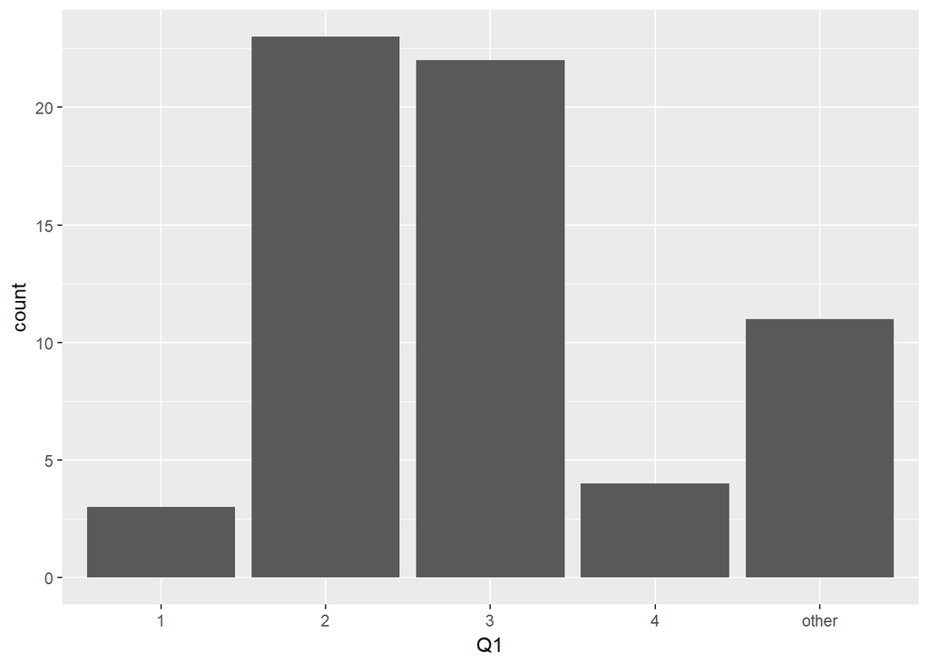

```r
ggplot(Survey_tidy) +
  geom_bar(aes(x=Q1))
```

Interpretation: from the graph we can see the most students taking this unit are in year 2 or 3. and only a small part of students are from year 1 or 4. While this subject is level 1, it is not a core first year subject, explaining the large number of non-first year students.

### Time spent studying compared to time spent on the internet

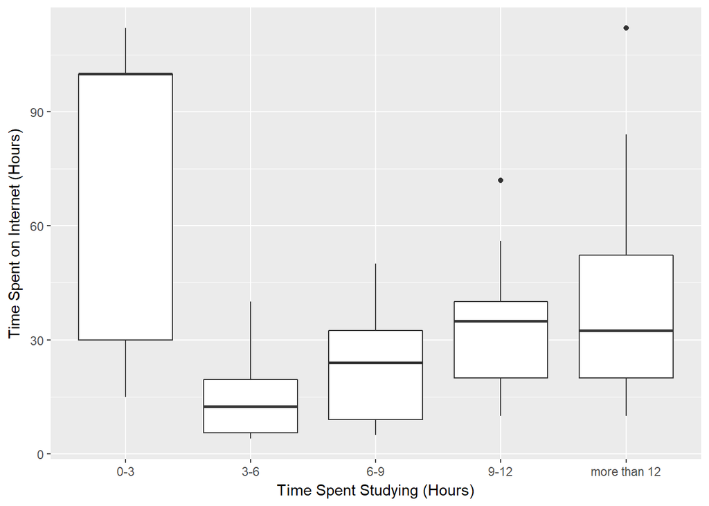

```r
ggplot(Survey_tidy) +
  geom_boxplot(aes(x = Q8, y = Q5)) +
  xlab("Time Spent Studying (Hours)") +
  ylab("Time Spent on Internet (Hours)")
```

### Do students put tomato sauce in the fridge or pantry

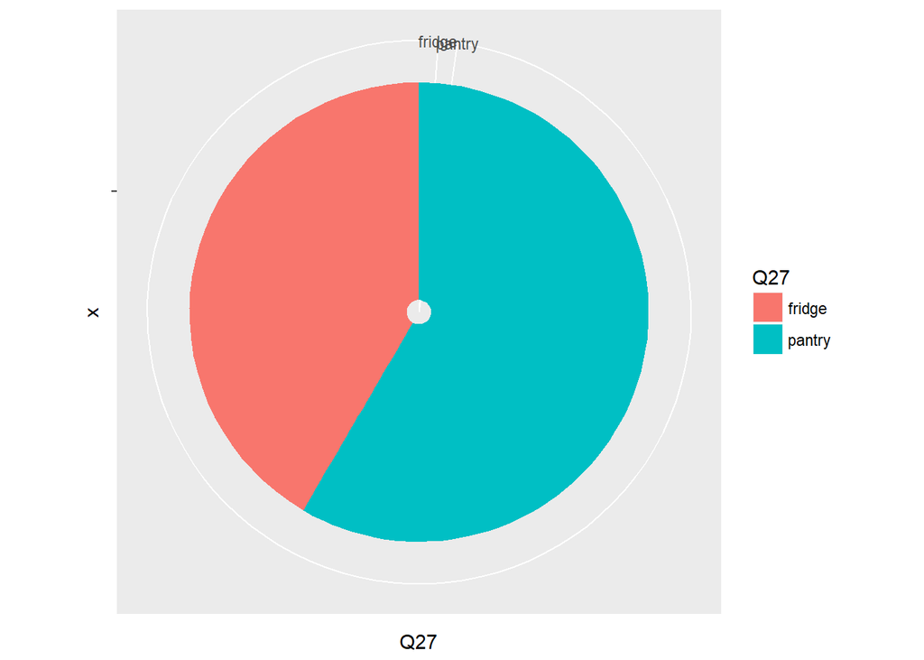

```r
ggplot(Survey_tidy) +
  geom_bar(aes(x = "", y = Q27, fill = Q27), stat = "identity") +
  coord_polar(theta = "y")
```

Intepretation: In the graph, the red represents tomato sauce in the fridge and the blue represents the pantry. The pie chart shows that the proportion of students putting tomato sauce in the pantry is larger than that in the fridge. We can see the difference is not expremely big, a large reason why the debate is often such a big issue (although no debate is required, as it definitely belongs in the pantry).

### Is there a relationship between students that like and enjoy this unit?

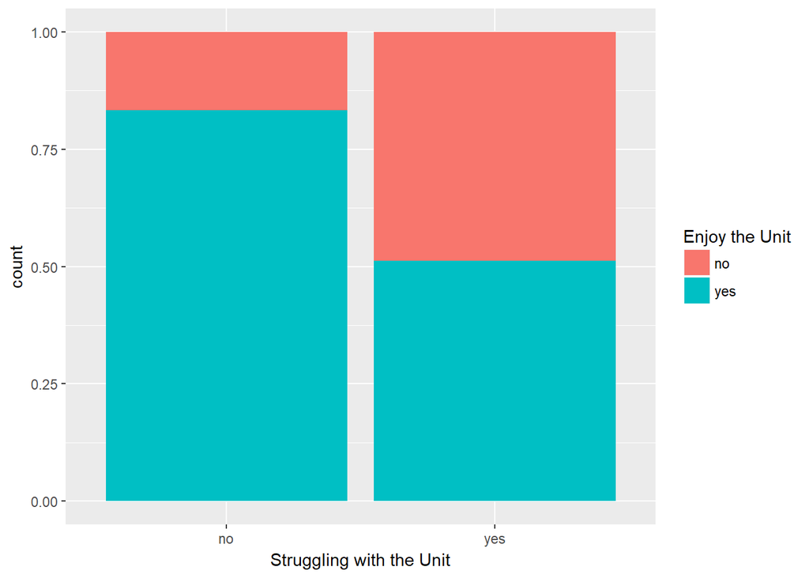

```r
ggplot(Survey_tidy) +
  geom_bar(aes(x = Q30, fill = Q31), position = "fill") +
  xlab("Struggling with the Unit")  +
  scale_fill_discrete(name="Enjoy the Unit")
```

Interpretation: The graph shows that for students struggling with this unit, half of them likes this unit and half do not like it. This indicates that simply struggling is not enough of a reason not to like it, there must be other factors at play. For students not struggling with it however, the majority of them likes it. This is probably as the unit is easy for them and does not require much work.

### Relationship between height and gender

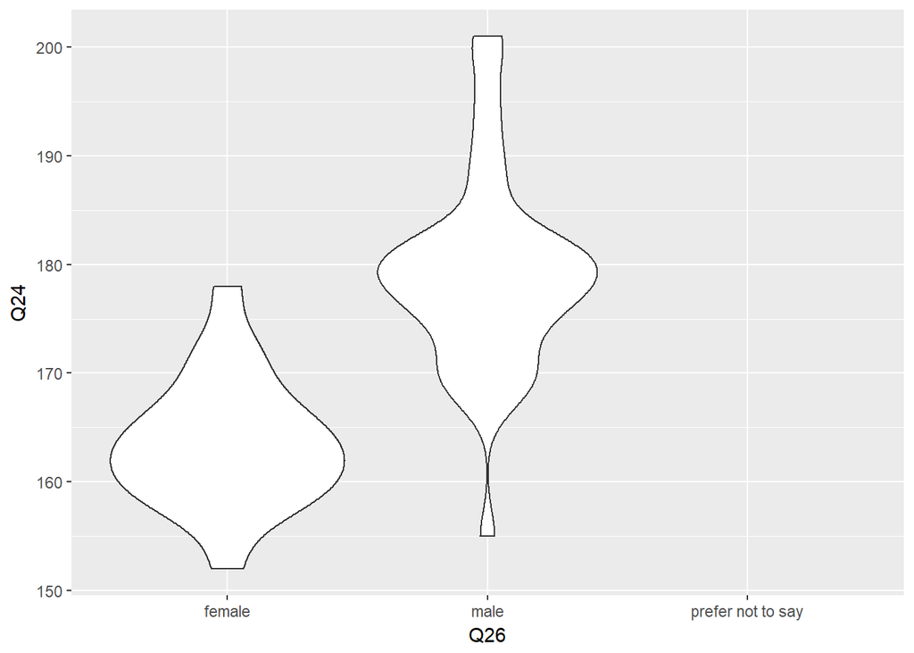

```r
ggplot(Survey_tidy) +
  geom_violin(aes(x = Q26, y = Q24))
```

Interpretation: This graph shows that there is a positive relation between gender and height as males are mostly taller than females. We can see that a bulk of the female heights lay just above 160 cm, while a large portion of males are just below 180 cm. The distribution for males is also much more spread out, with a max height just over 200cm compared to the max for woman under 180cm.

### Are we still growing (ie are older people taller?)

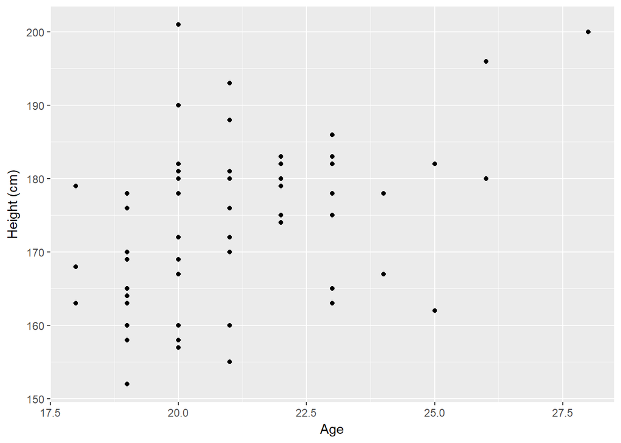

```r
ggplot(Survey_tidy) +
  geom_point(aes(x = Q23, y = Q24)) +
  xlab("Age") +
  ylab("Height (cm)")
```

Interpretation: From the graph we know that the correlation between age and height is very small, there is an extremely weak relationship between age and height.This is because most people have stopped growing by the time they reach their late /early 20s.

### What are the most common super powers

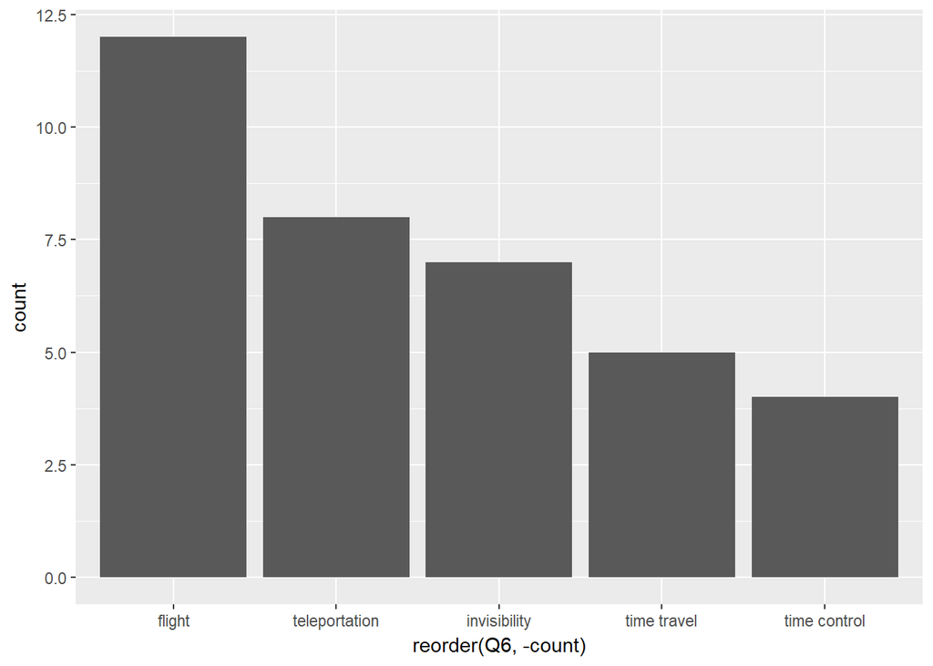

```r
ggplot(powers_summary) +
  geom_bar(aes(x = reorder(Q6,-count), weight = count))
```

Interpretation: The graph shows that the top five popular super powers are flight, teleportation, invisibility, time travel and time control. These were the only powers to feature at least 4 times, which makes sense as they are all common powers in superheros. Less common powers like ability to always get HD’s were chosen in the survey, but not enough to make this graph.

### What are the most common music choices

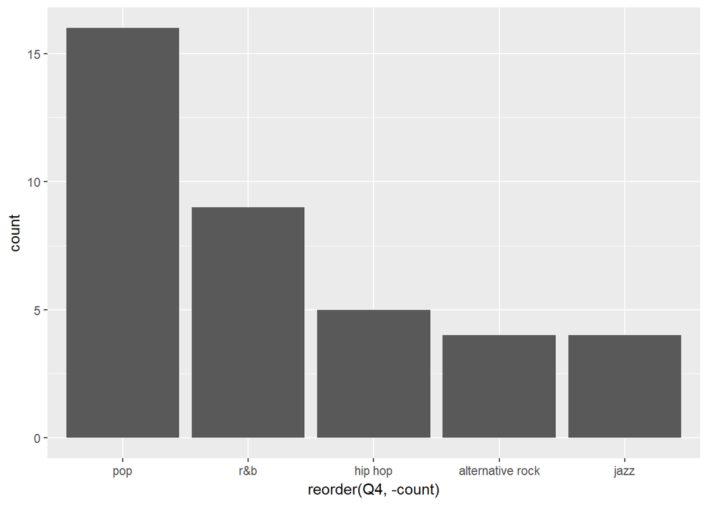

```r
ggplot(music_summary) +
  geom_bar(aes(x = reorder(Q4,-count), weight = count))
```

Interpretation: the bar chart shows that the top music type in the class is Pop and the second is R&B. The gap between pop and R&B is quite large, so we might say pop is the major trending music in today’s society. This trend is noticed on main radio stations who typically play pop music. R&B and hip hop are unsurprisingly next on the list, as this type of music often gets feature times on the radio as well and is often played at parties and in clubs.

### What operating system to people use that code/dont code

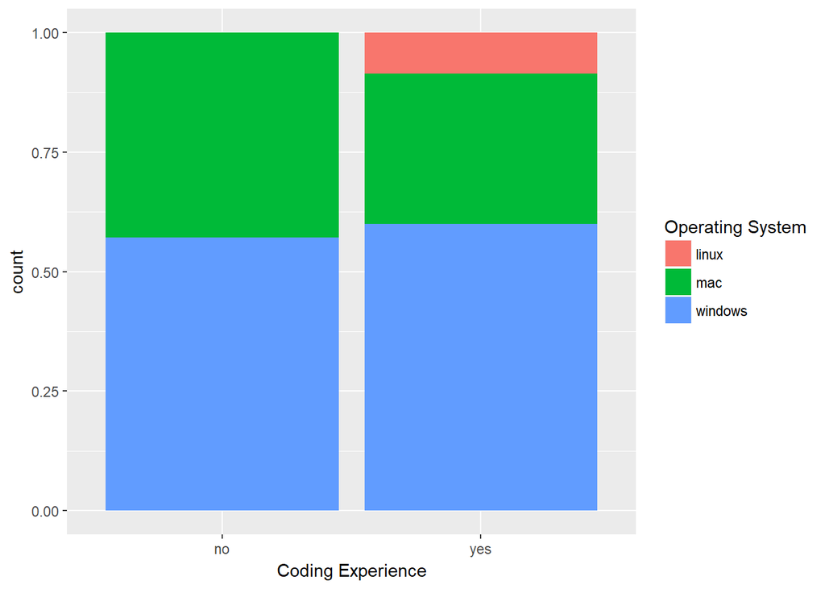

```r
ggplot(Survey_tidy) +
  geom_bar(aes(x = Q17, fill = Q19), position = "fill") +
  xlab("Coding Experience") +
  scale_fill_discrete(name="Operating System")
```

Intepretation: Overall there is not a great deal of difference between operating system for those with or without coding experience. For both windows is the most popular followed by mac. The only other point of note is no people without coding experience use linux. This is likely due to the nature of linux requiring more computing skills than the average computer user.

### Variation in pet ownership

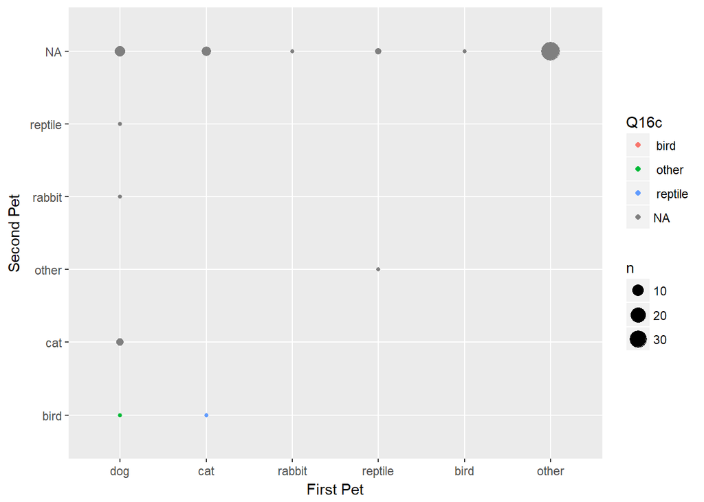

```r
ggplot(Survey_Q16) +
  geom_count(aes(x = Q16a, y = Q16b, color = Q16c)) +
  xlab("First Pet") +
  ylab("Second Pet") +
  scale_x_discrete(limits=c("dog","cat","rabbit","reptile","bird", "other"))
```

Interpretation: In this graph we can see the distribution of people and their pets. Due to the small number of pet owners in the class, the graph is not overly useful with the majority of students falling into the ‘other’ category for their first pet, while not having a second pet. As there was no option for no pet, many people would have picked ‘other’ when they don’t have a pet at all. For those with multiple pets, we can see that the dog is the most common as one of the pets. This makes sense are dogs are typically the most popular household pet (known as mans best friend). There are only 3 instances of 3 pets: (dog, bird, other), (cat, bird, reptile) and (dog, cat, bird). (This last point is unfortunately covered by the larger grey dot occuring in the same point).

# Conclusion

Overall the length of this code is testament to how much tidying data can require, especially given this data set only had 63 observations. From the data a great number of plots could be created, with only a handfuul shown. These graphs were chosen as they display the various different data forms obtained from the set and an example of the different possible graphs that could be created (ranging from bar to scatter to boxplots and more). This data could then be easily used to answer any questions related to the data and this class.

Talking about data tidying, there’s a trade off between time consumption of data tidying (complexity of the questionnaire) and what we’re trying to find from the questionnaire itself. If we have a more complex questionnaire (like this one) we can understand the situation better as it gives us many possible responses.The answers are not limited to what we provide. It helps us capture the situation more clearly However, it takes time to process. On the other hand, if we had chosen to use a simpler questions, we could process the responses quickly (no need to tidy even) but it might not capture the real condition